# Risk Factor Analysis

## Outcome Variable

**Outcome Variable:** ever_stunted

## Predictor Variables

**Intervention Variable:** fage

**Adjustment Set:**

unadjusted

## Stratifying Variables

The analysis was stratified on these variable(s):

- agecat
- studyid

The following strata were considered:

- agecat: 12 months, studyid: ki1000304b-SAS-CompFeed
- agecat: 12 months, studyid: ki1000304b-SAS-FoodSuppl
- agecat: 12 months, studyid: ki1119695-PROBIT
- agecat: 12 months, studyid: ki1135781-COHORTS
- agecat: 12 months, studyid: ki1148112-LCNI-5
- agecat: 18 months, studyid: ki1000304b-SAS-CompFeed
- agecat: 18 months, studyid: ki1000304b-SAS-FoodSuppl
- agecat: 18 months, studyid: ki1119695-PROBIT
- agecat: 18 months, studyid: ki1135781-COHORTS
- agecat: 18 months, studyid: ki1148112-LCNI-5
- agecat: 24 months, studyid: ki1000304b-SAS-CompFeed
- agecat: 24 months, studyid: ki1000304b-SAS-FoodSuppl
- agecat: 24 months, studyid: ki1119695-PROBIT
- agecat: 24 months, studyid: ki1135781-COHORTS
- agecat: 24 months, studyid: ki1148112-LCNI-5
- agecat: 3 months, studyid: ki1000304b-SAS-CompFeed
- agecat: 3 months, studyid: ki1119695-PROBIT
- agecat: 3 months, studyid: ki1135781-COHORTS
- agecat: 6 months, studyid: ki1000304b-SAS-CompFeed
- agecat: 6 months, studyid: ki1000304b-SAS-FoodSuppl
- agecat: 6 months, studyid: ki1119695-PROBIT
- agecat: 6 months, studyid: ki1135781-COHORTS
- agecat: 6 months, studyid: ki1148112-LCNI-5

## Methods Detail

# Results Detail

## Results Plots

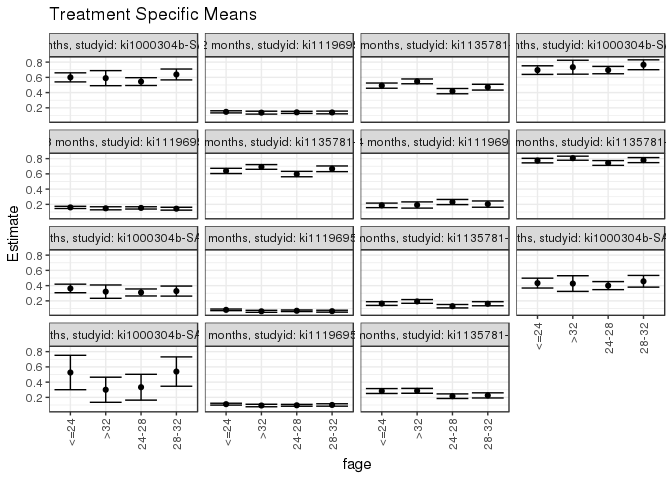

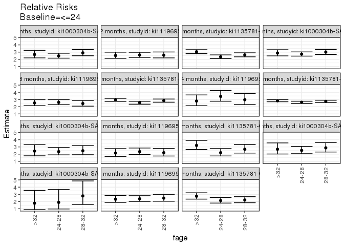

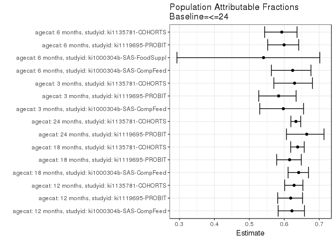

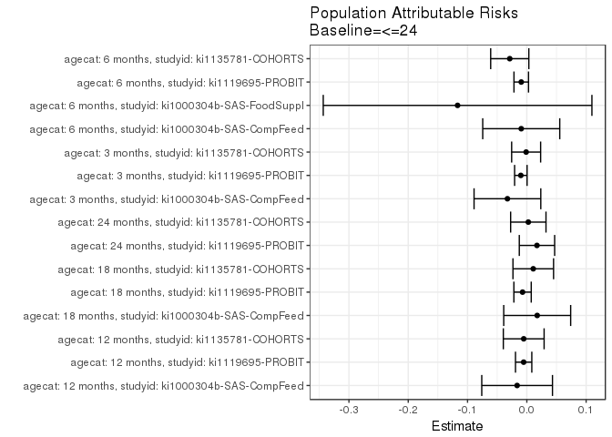

## Data Summary

| agecat | studyid | A | n | nA | nAY0 | nAY1 |
| --- | --- | --- | --- | --- | --- | --- |
| 12 months | ki1000304b-SAS-CompFeed | <=24 | 891 | 260 | 104 | 156 |
| 12 months | ki1000304b-SAS-CompFeed | >32 | 891 | 95 | 39 | 56 |
| 12 months | ki1000304b-SAS-CompFeed | 24-28 | 891 | 362 | 165 | 197 |
| 12 months | ki1000304b-SAS-CompFeed | 28-32 | 891 | 174 | 63 | 111 |
| 12 months | ki1000304b-SAS-FoodSuppl | <=24 | 99 | 18 | 2 | 16 |
| 12 months | ki1000304b-SAS-FoodSuppl | >32 | 99 | 28 | 3 | 25 |
| 12 months | ki1000304b-SAS-FoodSuppl | 24-28 | 99 | 26 | 5 | 21 |
| 12 months | ki1000304b-SAS-FoodSuppl | 28-32 | 99 | 27 | 5 | 22 |
| 12 months | ki1119695-PROBIT | <=24 | 7638 | 2555 | 2178 | 377 |
| 12 months | ki1119695-PROBIT | >32 | 7638 | 1243 | 1073 | 170 |
| 12 months | ki1119695-PROBIT | 24-28 | 7638 | 2413 | 2073 | 340 |
| 12 months | ki1119695-PROBIT | 28-32 | 7638 | 1427 | 1228 | 199 |
| 12 months | ki1135781-COHORTS | <=24 | 3211 | 814 | 414 | 400 |
| 12 months | ki1135781-COHORTS | >32 | 3211 | 950 | 430 | 520 |
| 12 months | ki1135781-COHORTS | 24-28 | 3211 | 785 | 456 | 329 |
| 12 months | ki1135781-COHORTS | 28-32 | 3211 | 662 | 350 | 312 |
| 12 months | ki1148112-LCNI-5 | <=24 | 47 | 7 | 3 | 4 |
| 12 months | ki1148112-LCNI-5 | >32 | 47 | 19 | 10 | 9 |
| 12 months | ki1148112-LCNI-5 | 24-28 | 47 | 11 | 7 | 4 |
| 12 months | ki1148112-LCNI-5 | 28-32 | 47 | 10 | 6 | 4 |
| 18 months | ki1000304b-SAS-CompFeed | <=24 | 860 | 256 | 78 | 178 |
| 18 months | ki1000304b-SAS-CompFeed | >32 | 860 | 90 | 24 | 66 |
| 18 months | ki1000304b-SAS-CompFeed | 24-28 | 860 | 348 | 106 | 242 |
| 18 months | ki1000304b-SAS-CompFeed | 28-32 | 860 | 166 | 39 | 127 |
| 18 months | ki1000304b-SAS-FoodSuppl | <=24 | 93 | 16 | 1 | 15 |
| 18 months | ki1000304b-SAS-FoodSuppl | >32 | 93 | 26 | 3 | 23 |
| 18 months | ki1000304b-SAS-FoodSuppl | 24-28 | 93 | 28 | 3 | 25 |
| 18 months | ki1000304b-SAS-FoodSuppl | 28-32 | 93 | 23 | 3 | 20 |
| 18 months | ki1119695-PROBIT | <=24 | 7201 | 2413 | 2027 | 386 |
| 18 months | ki1119695-PROBIT | >32 | 7201 | 1181 | 1006 | 175 |

[output cut: 70 more lines]

## Results Table

### Parameter: TSM

| agecat | studyid | intervention_level | baseline_level | estimate | ci_lower | ci_upper |
| --- | --- | --- | --- | --- | --- | --- |
| 12 months | ki1000304b-SAS-CompFeed | <=24 | NA | 0.6000000 | 0.5404186 | 0.6595814 |
| 12 months | ki1000304b-SAS-CompFeed | >32 | NA | 0.5894737 | 0.4904970 | 0.6884504 |
| 12 months | ki1000304b-SAS-CompFeed | 24-28 | NA | 0.5441989 | 0.4928650 | 0.5955328 |
| 12 months | ki1000304b-SAS-CompFeed | 28-32 | NA | 0.6379310 | 0.5664814 | 0.7093806 |
| 12 months | ki1119695-PROBIT | <=24 | NA | 0.1475538 | 0.1338011 | 0.1613066 |
| 12 months | ki1119695-PROBIT | >32 | NA | 0.1367659 | 0.1176632 | 0.1558686 |
| 12 months | ki1119695-PROBIT | 24-28 | NA | 0.1409034 | 0.1270206 | 0.1547863 |
| 12 months | ki1119695-PROBIT | 28-32 | NA | 0.1394534 | 0.1214785 | 0.1574283 |
| 12 months | ki1135781-COHORTS | <=24 | NA | 0.4914005 | 0.4570519 | 0.5257491 |
| 12 months | ki1135781-COHORTS | >32 | NA | 0.5473684 | 0.5157117 | 0.5790252 |
| 12 months | ki1135781-COHORTS | 24-28 | NA | 0.4191083 | 0.3845866 | 0.4536299 |
| 12 months | ki1135781-COHORTS | 28-32 | NA | 0.4712991 | 0.4332679 | 0.5093303 |
| 18 months | ki1000304b-SAS-CompFeed | <=24 | NA | 0.6953125 | 0.6388970 | 0.7517280 |
| 18 months | ki1000304b-SAS-CompFeed | >32 | NA | 0.7333333 | 0.6419189 | 0.8247477 |
| 18 months | ki1000304b-SAS-CompFeed | 24-28 | NA | 0.6954023 | 0.6470193 | 0.7437853 |
| 18 months | ki1000304b-SAS-CompFeed | 28-32 | NA | 0.7650602 | 0.7005286 | 0.8295919 |
| 18 months | ki1119695-PROBIT | <=24 | NA | 0.1599668 | 0.1453396 | 0.1745941 |
| 18 months | ki1119695-PROBIT | >32 | NA | 0.1481795 | 0.1279157 | 0.1684433 |
| 18 months | ki1119695-PROBIT | 24-28 | NA | 0.1532365 | 0.1384204 | 0.1680525 |
| 18 months | ki1119695-PROBIT | 28-32 | NA | 0.1429641 | 0.1241930 | 0.1617351 |
| 18 months | ki1135781-COHORTS | <=24 | NA | 0.6385224 | 0.6043154 | 0.6727294 |
| 18 months | ki1135781-COHORTS | >32 | NA | 0.6908046 | 0.6600893 | 0.7215199 |
| 18 months | ki1135781-COHORTS | 24-28 | NA | 0.5972973 | 0.5619552 | 0.6326394 |
| 18 months | ki1135781-COHORTS | 28-32 | NA | 0.6666667 | 0.6294943 | 0.7038390 |
| 24 months | ki1119695-PROBIT | <=24 | NA | 0.1869301 | 0.1571348 | 0.2167254 |
| 24 months | ki1119695-PROBIT | >32 | NA | 0.1916667 | 0.1509966 | 0.2323367 |
| 24 months | ki1119695-PROBIT | 24-28 | NA | 0.2305141 | 0.1968902 | 0.2641380 |
| 24 months | ki1119695-PROBIT | 28-32 | NA | 0.2032520 | 0.1621823 | 0.2443218 |
| 24 months | ki1135781-COHORTS | <=24 | NA | 0.7741083 | 0.7443146 | 0.8039021 |
| 24 months | ki1135781-COHORTS | >32 | NA | 0.8054245 | 0.7787756 | 0.8320735 |
| 24 months | ki1135781-COHORTS | 24-28 | NA | 0.7428571 | 0.7112549 | 0.7744594 |
| 24 months | ki1135781-COHORTS | 28-32 | NA | 0.7803661 | 0.7472618 | 0.8134703 |
| 3 months | ki1000304b-SAS-CompFeed | <=24 | NA | 0.3629893 | 0.3067373 | 0.4192413 |
| 3 months | ki1000304b-SAS-CompFeed | >32 | NA | 0.3211009 | 0.2334047 | 0.4087972 |
| 3 months | ki1000304b-SAS-CompFeed | 24-28 | NA | 0.3102564 | 0.2643215 | 0.3561913 |
| 3 months | ki1000304b-SAS-CompFeed | 28-32 | NA | 0.3282051 | 0.2622658 | 0.3941445 |
| 3 months | ki1119695-PROBIT | <=24 | NA | 0.0820611 | 0.0715511 | 0.0925710 |
| 3 months | ki1119695-PROBIT | >32 | NA | 0.0630418 | 0.0496691 | 0.0764145 |
| 3 months | ki1119695-PROBIT | 24-28 | NA | 0.0700972 | 0.0600239 | 0.0801706 |
| 3 months | ki1119695-PROBIT | 28-32 | NA | 0.0646492 | 0.0520088 | 0.0772897 |
| 3 months | ki1135781-COHORTS | <=24 | NA | 0.1647856 | 0.1403539 | 0.1892172 |
| 3 months | ki1135781-COHORTS | >32 | NA | 0.1923077 | 0.1677293 | 0.2168861 |
| 3 months | ki1135781-COHORTS | 24-28 | NA | 0.1298701 | 0.1072281 | 0.1525122 |
| 3 months | ki1135781-COHORTS | 28-32 | NA | 0.1625000 | 0.1355497 | 0.1894503 |
| 6 months | ki1000304b-SAS-CompFeed | <=24 | NA | 0.4330357 | 0.3681075 | 0.4979640 |
| 6 months | ki1000304b-SAS-CompFeed | >32 | NA | 0.4269663 | 0.3241386 | 0.5297939 |
| 6 months | ki1000304b-SAS-CompFeed | 24-28 | NA | 0.4000000 | 0.3471108 | 0.4528892 |
| 6 months | ki1000304b-SAS-CompFeed | 28-32 | NA | 0.4567901 | 0.3800358 | 0.5335444 |
| 6 months | ki1000304b-SAS-FoodSuppl | <=24 | NA | 0.5263158 | 0.3007273 | 0.7519043 |
| 6 months | ki1000304b-SAS-FoodSuppl | >32 | NA | 0.3000000 | 0.1352312 | 0.4647688 |
| 6 months | ki1000304b-SAS-FoodSuppl | 24-28 | NA | 0.3333333 | 0.1638374 | 0.5028292 |
| 6 months | ki1000304b-SAS-FoodSuppl | 28-32 | NA | 0.5384615 | 0.3459217 | 0.7310014 |
| 6 months | ki1119695-PROBIT | <=24 | NA | 0.1108462 | 0.0985808 | 0.1231117 |
| 6 months | ki1119695-PROBIT | >32 | NA | 0.0932897 | 0.0769820 | 0.1095974 |
| 6 months | ki1119695-PROBIT | 24-28 | NA | 0.0961620 | 0.0842945 | 0.1080294 |
| 6 months | ki1119695-PROBIT | 28-32 | NA | 0.1004989 | 0.0847653 | 0.1162326 |
| 6 months | ki1135781-COHORTS | <=24 | NA | 0.2834437 | 0.2512916 | 0.3155958 |
| 6 months | ki1135781-COHORTS | >32 | NA | 0.2857143 | 0.2538003 | 0.3176283 |
| 6 months | ki1135781-COHORTS | 24-28 | NA | 0.2156593 | 0.1857783 | 0.2455403 |
| 6 months | ki1135781-COHORTS | 28-32 | NA | 0.2257525 | 0.1922382 | 0.2592668 |

### Parameter: E(Y)

| agecat | studyid | intervention_level | baseline_level | estimate | ci_lower | ci_upper |
| --- | --- | --- | --- | --- | --- | --- |
| 12 months | ki1000304b-SAS-CompFeed | NA | NA | 0.5836139 | 0.5812549 | 0.5859730 |
| 12 months | ki1119695-PROBIT | NA | NA | 0.1421838 | 0.1420932 | 0.1422745 |
| 12 months | ki1135781-COHORTS | NA | NA | 0.4861414 | 0.4844968 | 0.4877860 |
| 18 months | ki1000304b-SAS-CompFeed | NA | NA | 0.7127907 | 0.7109173 | 0.7146641 |
| 18 months | ki1119695-PROBIT | NA | NA | 0.1527566 | 0.1526128 | 0.1529003 |
| 18 months | ki1135781-COHORTS | NA | NA | 0.6493637 | 0.6480883 | 0.6506391 |
| 24 months | ki1119695-PROBIT | NA | NA | 0.2040201 | 0.2032134 | 0.2048268 |
| 24 months | ki1135781-COHORTS | NA | NA | 0.7766066 | 0.7757755 | 0.7774377 |
| 3 months | ki1000304b-SAS-CompFeed | NA | NA | 0.3302564 | 0.3288819 | 0.3316309 |
| 3 months | ki1119695-PROBIT | NA | NA | 0.0719498 | 0.0717806 | 0.0721190 |
| 3 months | ki1135781-COHORTS | NA | NA | 0.1636152 | 0.1628552 | 0.1643753 |
| 6 months | ki1000304b-SAS-CompFeed | NA | NA | 0.4236025 | 0.4220944 | 0.4251106 |
| 6 months | ki1000304b-SAS-FoodSuppl | NA | NA | 0.4095238 | 0.3887613 | 0.4302864 |
| 6 months | ki1119695-PROBIT | NA | NA | 0.1014242 | 0.1012653 | 0.1015831 |
| 6 months | ki1135781-COHORTS | NA | NA | 0.2546475 | 0.2534615 | 0.2558335 |

### Parameter: RR

| agecat | studyid | intervention_level | baseline_level | estimate | ci_lower | ci_upper |
| --- | --- | --- | --- | --- | --- | --- |
| 12 months | ki1000304b-SAS-CompFeed | >32 | <=24 | 2.671009 | 2.1976369 | 3.246345 |
| 12 months | ki1000304b-SAS-CompFeed | 24-28 | <=24 | 2.476876 | 2.1598413 | 2.840447 |
| 12 months | ki1000304b-SAS-CompFeed | 28-32 | <=24 | 2.895675 | 2.4931176 | 3.363233 |
| 12 months | ki1119695-PROBIT | >32 | <=24 | 2.526635 | 2.1360778 | 2.988600 |
| 12 months | ki1119695-PROBIT | 24-28 | <=24 | 2.598486 | 2.2689143 | 2.975931 |
| 12 months | ki1119695-PROBIT | 28-32 | <=24 | 2.573076 | 2.1946849 | 3.016706 |
| 12 months | ki1135781-COHORTS | >32 | <=24 | 3.046200 | 2.7820032 | 3.335485 |
| 12 months | ki1135781-COHORTS | 24-28 | <=24 | 2.346407 | 2.1061353 | 2.614090 |
| 12 months | ki1135781-COHORTS | 28-32 | <=24 | 2.609330 | 2.3451151 | 2.903314 |
| 18 months | ki1000304b-SAS-CompFeed | >32 | <=24 | 2.871061 | 2.4742714 | 3.331482 |
| 18 months | ki1000304b-SAS-CompFeed | 24-28 | <=24 | 2.718633 | 2.4430477 | 3.025305 |
| 18 months | ki1000304b-SAS-CompFeed | 28-32 | <=24 | 3.005101 | 2.6731928 | 3.378221 |
| 18 months | ki1119695-PROBIT | >32 | <=24 | 2.525184 | 2.1421455 | 2.976713 |
| 18 months | ki1119695-PROBIT | 24-28 | <=24 | 2.606286 | 2.2815362 | 2.977261 |
| 18 months | ki1119695-PROBIT | 28-32 | <=24 | 2.444182 | 2.0827912 | 2.868279 |
| 18 months | ki1135781-COHORTS | >32 | <=24 | 2.950220 | 2.7518129 | 3.162933 |
| 18 months | ki1135781-COHORTS | 24-28 | <=24 | 2.548326 | 2.3528273 | 2.760069 |
| 18 months | ki1135781-COHORTS | 28-32 | <=24 | 2.840776 | 2.6293935 | 3.069151 |
| 24 months | ki1119695-PROBIT | >32 | <=24 | 2.788040 | 2.1381690 | 3.635431 |
| 24 months | ki1119695-PROBIT | 24-28 | <=24 | 3.432046 | 2.7651510 | 4.259783 |
| 24 months | ki1119695-PROBIT | 28-32 | <=24 | 2.966301 | 2.2932110 | 3.836953 |
| 24 months | ki1135781-COHORTS | >32 | <=24 | 2.830503 | 2.6904265 | 2.977873 |
| 24 months | ki1135781-COHORTS | 24-28 | <=24 | 2.610729 | 2.4651716 | 2.764881 |
| 24 months | ki1135781-COHORTS | 28-32 | <=24 | 2.740345 | 2.5877913 | 2.901892 |
| 3 months | ki1000304b-SAS-CompFeed | >32 | <=24 | 2.422019 | 1.7693056 | 3.315525 |
| 3 months | ki1000304b-SAS-CompFeed | 24-28 | <=24 | 2.350730 | 1.8972402 | 2.912616 |
| 3 months | ki1000304b-SAS-CompFeed | 28-32 | <=24 | 2.469888 | 1.9163864 | 3.183256 |
| 3 months | ki1119695-PROBIT | >32 | <=24 | 2.155947 | 1.6827674 | 2.762180 |
| 3 months | ki1119695-PROBIT | 24-28 | <=24 | 2.349514 | 1.9381104 | 2.848245 |
| 3 months | ki1119695-PROBIT | 28-32 | <=24 | 2.198595 | 1.7403434 | 2.777510 |
| 3 months | ki1135781-COHORTS | >32 | <=24 | 3.212399 | 2.6412994 | 3.906980 |
| 3 months | ki1135781-COHORTS | 24-28 | <=24 | 2.199249 | 1.7493669 | 2.764827 |
| 3 months | ki1135781-COHORTS | 28-32 | <=24 | 2.680840 | 2.1461424 | 3.348754 |
| 6 months | ki1000304b-SAS-CompFeed | >32 | <=24 | 2.680448 | 2.0183711 | 3.559703 |
| 6 months | ki1000304b-SAS-CompFeed | 24-28 | <=24 | 2.518620 | 2.0622571 | 3.075974 |
| 6 months | ki1000304b-SAS-CompFeed | 28-32 | <=24 | 2.871560 | 2.2925281 | 3.596841 |
| 6 months | ki1000304b-SAS-FoodSuppl | >32 | <=24 | 1.768267 | 0.8810133 | 3.549059 |
| 6 months | ki1000304b-SAS-FoodSuppl | 24-28 | <=24 | 1.883880 | 0.9687943 | 3.663319 |
| 6 months | ki1000304b-SAS-FoodSuppl | 28-32 | <=24 | 2.781741 | 1.5918390 | 4.861096 |
| 6 months | ki1119695-PROBIT | >32 | <=24 | 2.320107 | 1.8865090 | 2.853365 |
| 6 months | ki1119695-PROBIT | 24-28 | <=24 | 2.381012 | 2.0173232 | 2.810268 |
| 6 months | ki1119695-PROBIT | 28-32 | <=24 | 2.476018 | 2.0440622 | 2.999256 |
| 6 months | ki1135781-COHORTS | >32 | <=24 | 2.740145 | 2.3368715 | 3.213010 |
| 6 months | ki1135781-COHORTS | 24-28 | <=24 | 2.140104 | 1.7892326 | 2.559781 |
| 6 months | ki1135781-COHORTS | 28-32 | <=24 | 2.217684 | 1.8397521 | 2.673252 |

### Parameter: PAR

| agecat | studyid | intervention_level | baseline_level | estimate | ci_lower | ci_upper |
| --- | --- | --- | --- | --- | --- | --- |
| 12 months | ki1000304b-SAS-CompFeed | <=24 | NA | -0.0163861 | -0.0760142 | 0.0432420 |
| 12 months | ki1119695-PROBIT | <=24 | NA | -0.0053700 | -0.0191231 | 0.0083831 |
| 12 months | ki1135781-COHORTS | <=24 | NA | -0.0052591 | -0.0396471 | 0.0291289 |
| 18 months | ki1000304b-SAS-CompFeed | <=24 | NA | 0.0174782 | -0.0389684 | 0.0739247 |
| 18 months | ki1119695-PROBIT | <=24 | NA | -0.0072103 | -0.0218382 | 0.0074177 |
| 18 months | ki1135781-COHORTS | <=24 | NA | 0.0108413 | -0.0233895 | 0.0450720 |
| 24 months | ki1119695-PROBIT | <=24 | NA | 0.0170900 | -0.0127162 | 0.0468962 |
| 24 months | ki1135781-COHORTS | <=24 | NA | 0.0024983 | -0.0273071 | 0.0323036 |
| 3 months | ki1000304b-SAS-CompFeed | <=24 | NA | -0.0327329 | -0.0890017 | 0.0235359 |
| 3 months | ki1119695-PROBIT | <=24 | NA | -0.0101113 | -0.0206226 | 0.0004001 |
| 3 months | ki1135781-COHORTS | <=24 | NA | -0.0011703 | -0.0256138 | 0.0232732 |
| 6 months | ki1000304b-SAS-CompFeed | <=24 | NA | -0.0094332 | -0.0743790 | 0.0555125 |
| 6 months | ki1000304b-SAS-FoodSuppl | <=24 | NA | -0.1167920 | -0.3433339 | 0.1097500 |
| 6 months | ki1119695-PROBIT | <=24 | NA | -0.0094220 | -0.0216885 | 0.0028445 |
| 6 months | ki1135781-COHORTS | <=24 | NA | -0.0287962 | -0.0609702 | 0.0033778 |

### Parameter: PAF

| agecat | studyid | intervention_level | baseline_level | estimate | ci_lower | ci_upper |
| --- | --- | --- | --- | --- | --- | --- |
| 12 months | ki1000304b-SAS-CompFeed | <=24 | NA | 0.6219353 | 0.5824309 | 0.6577023 |
| 12 months | ki1119695-PROBIT | <=24 | NA | 0.6184855 | 0.5812157 | 0.6524385 |
| 12 months | ki1135781-COHORTS | <=24 | NA | 0.6281623 | 0.6012085 | 0.6532943 |
| 18 months | ki1000304b-SAS-CompFeed | <=24 | NA | 0.6412528 | 0.6109151 | 0.6692249 |
| 18 months | ki1119695-PROBIT | <=24 | NA | 0.6151595 | 0.5783089 | 0.6487898 |
| 18 months | ki1135781-COHORTS | <=24 | NA | 0.6383139 | 0.6183955 | 0.6571927 |
| 24 months | ki1119695-PROBIT | <=24 | NA | 0.6642621 | 0.6062278 | 0.7137433 |
| 24 months | ki1135781-COHORTS | <=24 | NA | 0.6333059 | 0.6189119 | 0.6471563 |
| 3 months | ki1000304b-SAS-CompFeed | <=24 | NA | 0.5974049 | 0.5298951 | 0.6552200 |
| 3 months | ki1119695-PROBIT | <=24 | NA | 0.5838809 | 0.5270130 | 0.6339115 |
| 3 months | ki1135781-COHORTS | <=24 | NA | 0.6294985 | 0.5702544 | 0.6805754 |
| 6 months | ki1000304b-SAS-CompFeed | <=24 | NA | 0.6240188 | 0.5631810 | 0.6763834 |
| 6 months | ki1000304b-SAS-FoodSuppl | <=24 | NA | 0.5407200 | 0.2928334 | 0.7017137 |
| 6 months | ki1119695-PROBIT | <=24 | NA | 0.5994830 | 0.5526146 | 0.6414414 |
| 6 months | ki1135781-COHORTS | <=24 | NA | 0.5927817 | 0.5438240 | 0.6364852 |